# cleaning3

## Cleaning Data (Part 3): Titanic

```r
library(tidyverse)
library(skimr)
library(esquisse)
library(readxl) #for loading data from Excel files
library(janitor) #for data cleaning help
library(naniar) #visualizing missingness
library(mice) #imputation
library(titanic) #package for Titanic data
```

Load the data

```r
titanic = titanic::titanic_train
```

Examine the dataset

```r
str(titanic)
```

```
'data.frame':   891 obs. of  12 variables:
 $ PassengerId: int  1 2 3 4 5 6 7 8 9 10 ...
 $ Survived   : int  0 1 1 1 0 0 0 0 1 1 ...
 $ Pclass     : int  3 1 3 1 3 3 1 3 3 2 ...
 $ Name       : chr  "Braund, Mr. Owen Harris" "Cumings, Mrs. John Bradley (Florence Briggs Thayer)" "Heikkinen, Miss. Laina" "Futrelle, Mrs. Jacques Heath (Lily May Peel)" ...
 $ Sex        : chr  "male" "female" "female" "female" ...
 $ Age        : num  22 38 26 35 35 NA 54 2 27 14 ...
 $ SibSp      : int  1 1 0 1 0 0 0 3 0 1 ...
 $ Parch      : int  0 0 0 0 0 0 0 1 2 0 ...
 $ Ticket     : chr  "A/5 21171" "PC 17599" "STON/O2. 3101282" "113803" ...
 $ Fare       : num  7.25 71.28 7.92 53.1 8.05 ...
 $ Cabin      : chr  "" "C85" "" "C123" ...
 $ Embarked   : chr  "S" "C" "S" "S" ...
```

There are several variables that we are not going to work with, so we are going to go ahead and delete them. As usual, we use “select” for this.

## STEP 1 DATA TYPES

Categorical = factors

Names are not categorical

## STEP 2 MISSING DATA

```r
titanic = titanic %>% select(-PassengerId, -Name,-Ticket,-Fare,-Cabin,-Embarked)
```

What are our data cleaning tasks?

# removal of variables

We start by examining and converting data types. We then deal with missing data.

What variables in this dataset should be considered to be categorical?

```r
titanic = titanic %>% mutate(Survived = as_factor(Survived)) %>%
  mutate(Pclass = as_factor(Pclass)) %>%
  mutate(Sex = as_factor(Sex))
```

# Change the data names/desc.

*Factor = categorical data*

*Factors have levels*

*Levels = categories*

It will also be useful for us to recode some of the levels (categories).

# Changing nums to yes/no, etc.

```r
titanic = titanic %>% mutate(Survived = fct_recode(Survived, "No" = "0", "Yes" = "1" )) %>%
  mutate(Pclass = fct_recode(Pclass, "3rd" = "3", "2nd" = "2", "1st" = "1"))
```

# Missing data is shown by NA

Imputation to create age values

```r
summary(titanic)
```

```
 Survived  Pclass        Sex           Age            SibSp
 No :549   1st:216   male  :577   Min.   : 0.42   Min.   :0.000
 Yes:342   2nd:184   female:314   1st Qu.:20.12   1st Qu.:0.000
           3rd:491                Median :28.00   Median :0.000
                                  Mean   :29.70   Mean   :0.523
                                  3rd Qu.:38.00   3rd Qu.:1.000
                                  Max.   :80.00   Max.   :8.000
                                  NA's   :177
     Parch
 Min.   :0.0000
 1st Qu.:0.0000
 Median :0.0000
 Mean   :0.3816
 3rd Qu.:0.0000
 Max.   :6.0000
```

Now we look at missingness. The only missing values are in the Age variable.

*gg_miss_upset(name) was what we used before*

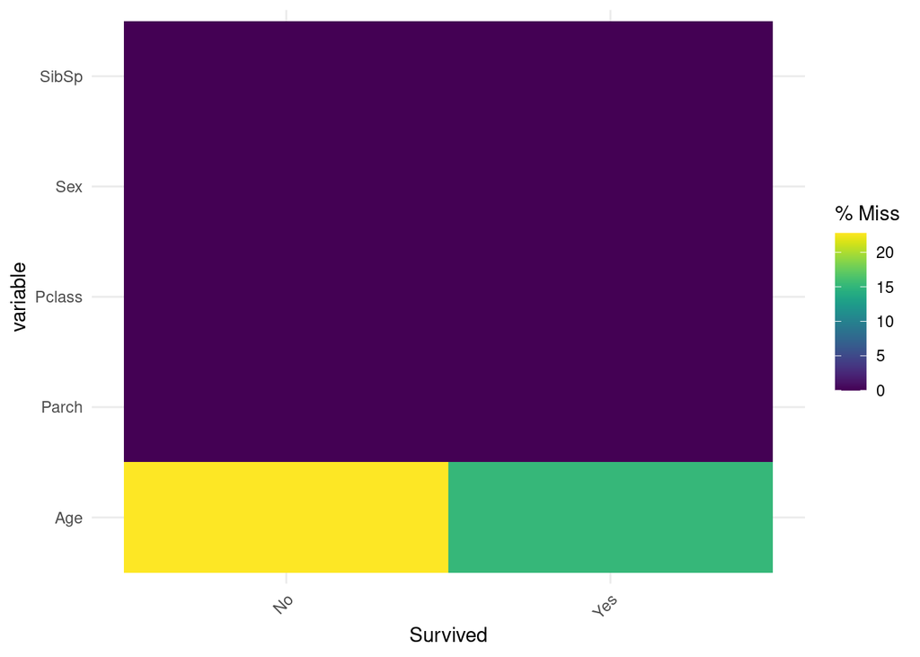

```r
# gg_miss_upset(titanic) #this plot works when you have two or more variables with missing values
#we can examine missingness of Age by factors such as Survived, Pclass, and Sex
#what does this analysis tell us?
gg_miss_fct(titanic,Survived)
```

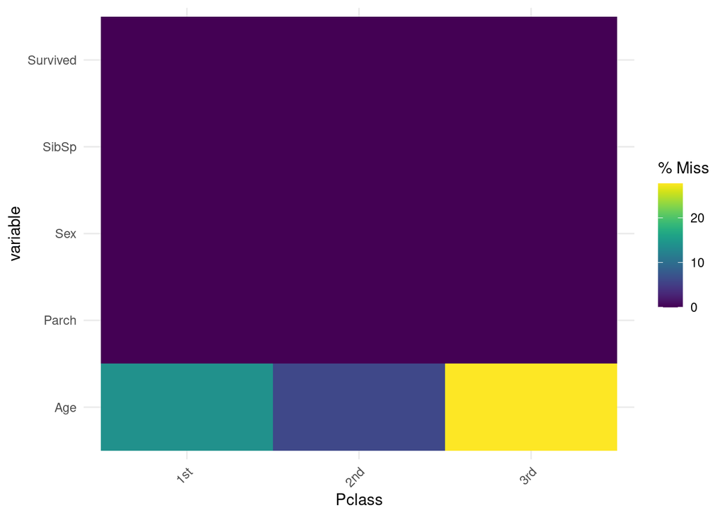

```r
gg_miss_fct(titanic,Pclass)
```

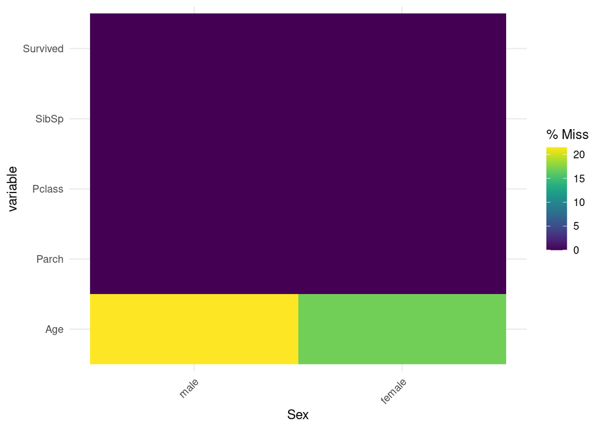

```r
gg_miss_fct(titanic,Sex)
```

Let’s impute the missing values for age using the mice package.

# Predictive Mean Matching

seed needs a “collective” point

*seeds will be told*

```r
set.seed(1234) #sets seed for random number generator
imp_age = mice(titanic, m=5, method='pmm', printFlag=FALSE)
#m is the number of imputations, 5 is a reasonable value as a default
#pmm is "predictive mean matching" this is the imputation method for numeric data
#printFlag reduces amount of output
summary(imp_age)
```

```
Class: mids
Number of multiple imputations:  5
Imputation methods:
Survived   Pclass      Sex      Age    SibSp    Parch
      ""       ""       ""    "pmm"       ""       ""
PredictorMatrix:
         Survived Pclass Sex Age SibSp Parch
Survived        0      1   1   1     1     1
Pclass          1      0   1   1     1     1
Sex             1      1   0   1     1     1
Age             1      1   1   0     1     1
SibSp           1      1   1   1     0     1
Parch           1      1   1   1     1     0
```

Plot the imputed values to see how they compare to the original.

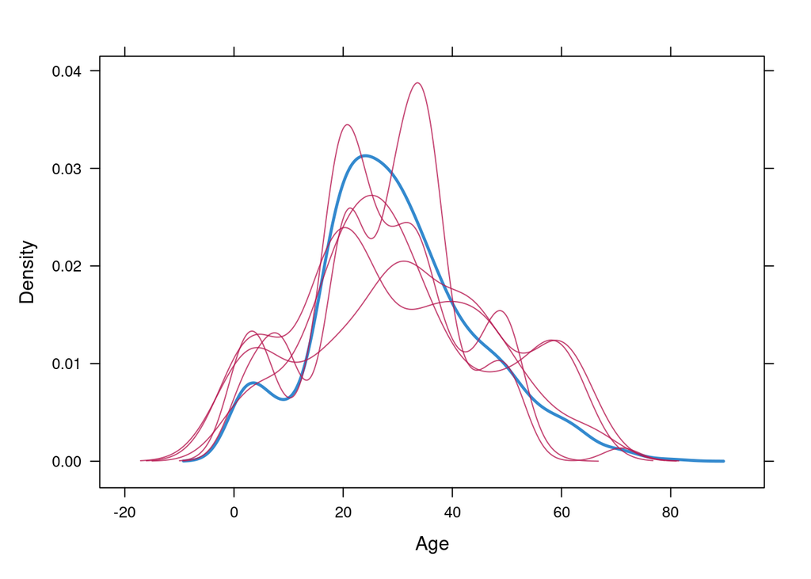

```r
densityplot(imp_age, ~Age) #red imputed, blue original
```

The general shape of the imputed values seems to align reasonably with the actual values. There is considerable variation, but that’s probably reasonable.

If we are satisfied with the imputed values, we can merge them into the dataset:

```r
titanic_complete = complete(imp_age)
```

```r
summary(titanic_complete)
```

```
 Survived  Pclass        Sex           Age            SibSp
 No :549   1st:216   male  :577   Min.   : 0.42   Min.   :0.000
 Yes:342   2nd:184   female:314   1st Qu.:19.00   1st Qu.:0.000
           3rd:491                Median :28.00   Median :0.000
                                  Mean   :29.32   Mean   :0.523
                                  3rd Qu.:39.00   3rd Qu.:1.000
                                  Max.   :80.00   Max.   :8.000
     Parch
 Min.   :0.0000
 1st Qu.:0.0000
 Median :0.0000
 Mean   :0.3816
 3rd Qu.:0.0000
 Max.   :6.0000
```

We should check the Age variable to make sure that no illogical values were generated. For example, there should be no negative values for Age. It looks like we are OK here.

With the data cleaned and prepared for analysis, we now move to the next step of the analytics process: visualization. We need to make sure that we choose the correct visualization type for each variable.

When we build predictive models with this data later, we’ll try to predict Survived. So, we’ll visualize relative to that variable.